# Tutorial on estimation of network models

As in the previous tutorial, the gray boxes indicate the code, the white boxes indicate the output in R, and the rest is the text/explanations.

The package `statnet` allows you to estimate both logistic models and ERGMs. To install the package on your computer, use the command

```r
install.packages("statnet", dependencies=TRUE, repos="http://lib.stat.cmu.edu/R/CRAN/")
install.packages("ergm.count", dependencies=TRUE, repos="http://lib.stat.cmu.edu/R/CRAN/")
install.packages("latticeExtra", dependencies=TRUE, repos="http://lib.stat.cmu.edu/R/CRAN/")
```

It is important that you use the option `dependencies=TRUE`, because you need to install several packages in addition to the base package: this option will take care of that.

To use the library you just type (there is a lot of output, because `R` loads many different packages, so be patient)

```r
# load the library
library(statnet)
```

The package contains several network datasets. You can get a list of the data included by typing

```r
# check data in the package
data(package="ergm")
```

Let’s use a dataset we are familiar with: the network of florentine families.

```r
# load data of florentine families
data(florentine)
```

The data contains the network of marriages and business relationships among the families. In addition there are three variables for each family: wealth (in thousands of lira), number of priorates (seats on the civic council), and totalities (total number of business ties and marriages in the dataset). To see a quick description we type

```r
# network of marriages
flomarriage
```

and to see a brief desctiption of the business links we type

```r
# network of business relationships
flobusiness
```

We can plot the network to get a better picture (note that this package has slightly different syntax than `igraph`). Here is the marriage network

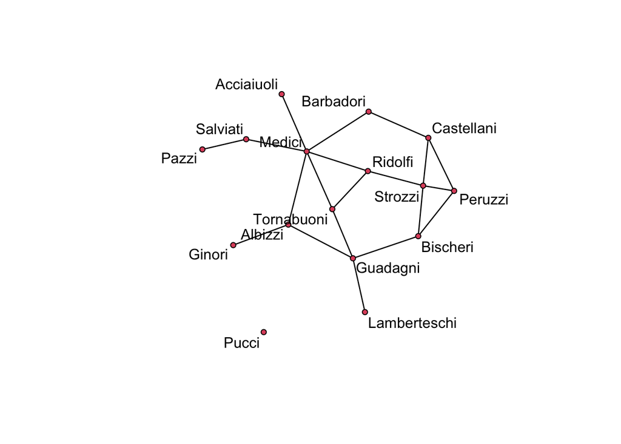

```r
# plot network of marriages
set.seed(1977)
plot(flomarriage, displaylabels=TRUE )
```

and the business network is shown below

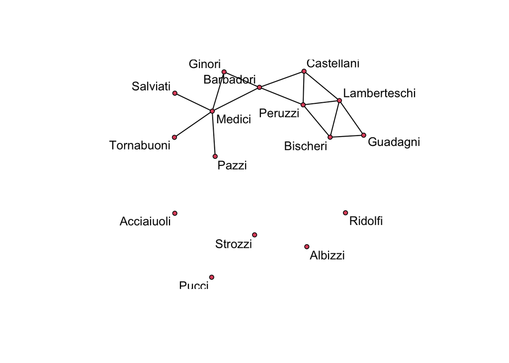

```r
# plot network of business
set.seed(1977)
plot(flobusiness, displaylabels=TRUE )
```

## Logistic regression models

Now we want to estimate a logistic regression model. We model the probability that two families have a marriage connection as a function of a constant and the sum of their wealth

$$\ln\left[\frac{P(g_{ij}=1)}{P(g_{ij}=0)}\right] = \beta_{0}+\beta_{1}\left(x_{i}+x_{j}\right)$$

This is accomplished with the command

```r
# estimate logistic regression model
model1<-ergm(flomarriage~edges +nodecov("wealth"), estimate="MPLE" )
```

```
## Starting maximum pseudolikelihood estimation (MPLE):
```

```
## Evaluating the predictor and response matrix.
```

```
## Maximizing the pseudolikelihood.
```

```
## Finished MPLE.
```

```
## Stopping at the initial estimate.
```

```
## Evaluating log-likelihood at the estimate.
```

The option `estimate="MPLE"` tells `R` to estimate a logistic regression model.

To understand the notation, it is better to rewrite the model in terms of the probability for the entire network, instead of looking at a single link. It can be shown that the probability of observing network $g$ is

$$P(g;\beta,x) = \frac{\exp\left[\beta_{0}\sum_{i=1}^{n}\sum_{j\neq
i}^{n}g_{ij}+\beta_{1}\sum_{i=1}^{n}\sum_{j\neq
i}^{n}g_{ij}\left(x_{i}+x_{j}\right)\right]}{\prod_{i=1,j\neq
i}\left[1+\exp\left(\beta_{0}+\beta_{1}\left(x_{i}+x_{j}\right)\right)\right]}$$

What does the numerator represents?

. $\sum_{i=1}^{n}\sum_{j\neq i}^{n}g_{ij}$= `edges` = number of links/edges in the network

. $\sum_{i=1}^{n}\sum_{j\neq i}^{n}g_{ij}\left(x_{i}+x_{j}\right)$ = `nodecov("wealth")` = number of links/edges in the network, weighted by the sum of wealth of the nodes forming the link

So in `R` we write the formula `flomarriage ~ edges + nodecov("wealth")` to estimate the model.  
To check the estimation results we type

```r
# show results of logistic regression model
summary(model1)
```

```
## Call:
## ergm(formula = flomarriage ~ edges + nodecov("wealth"), estimate = "MPLE")
##
## Maximum Likelihood Results:
##
##                 Estimate Std. Error MCMC % z value Pr(>|z|)
## edges          -2.594929   0.536056      0  -4.841   <1e-04 ***
## nodecov.wealth  0.010546   0.004674      0   2.256   0.0241 *
## ---
## Signif. codes:  0 '***' 0.001 '**' 0.01 '*' 0.05 '.' 0.1 ' ' 1
##
## For this model, the pseudolikelihood is the same as the likelihood.
##
##      Null Deviance: 166.4  on 120  degrees of freedom
##  Residual Deviance: 103.1  on 118  degrees of freedom
##
## AIC: 107.1  BIC: 112.7  (Smaller is better. MC Std. Err. = 0)
```

Interpreting the results is important. The output of the software provides the `Formula` of the model that we estimated. The `Iterations` have no meaning in this model, so we do not care.
The table with `Maximum Likelihood Results` is the most important part. Here the output reports the estimated parameters (`Estimate`), the standard error (`Std. Error`), the Monte Carlo standard error (`MCMC %`) and the p-value for the t-tests (`p-value`). The stars are associated with the significance level of the estimated parameters. Remember, the smaller the p-value, the more confident we are about rejecting the hypothesis that our parameters are equal to zero. The `Null Deviance` is the fit of a null model, with no explanatory variables. The `Residual Deviance` is the fit of our model. As a rule of thumb you want some difference between the two numbers, otherwise your explanatory variables are not good predictors for the links.
The `AIC` and `BIC` indicators are used to compare different models. So if you have several alternative models that you are considering, the rule of thumb is to prefer the one with the smallest AIC and BIC.
In this model we estimate $\beta_{0}=-2.59$ and $\beta_{1}=0.01$, so our estimated model is
$$\ln\left[\frac{P(g_{ij}=1)}{P(g_{ij}=0)}\right] = -2.59+0.01\left(x_{i}+x_{j}\right)$$
and the probability of a link between *i* and *j* is estimated as

$$P(g_{ij}=1) = \frac{ \exp\left[
-2.59+0.01\left(x_{i}+x_{j}\right) \right] }{1+ \exp\left[
-2.59+0.01\left(x_{i}+x_{j}\right) \right]}$$
We can now compute the probability of a link between two families that have zero wealth, for example, i.e. $x_{i}=x_{j}=0$,

$$P(g_{ij}=1) = \frac{ \exp\left[ -2.59
\right] }{1+ \exp\left[ -2.59\right]} =0.0697848$$

Let’s compute the probability of a link between two families that have different wealth, for example, i.e. $x_{i}=10$ and $x_{j}=2$,

$$P(g_{ij}=1) = \frac{ \exp\left[ -2.59 +
0.01 \left(10+2\right) \right] }{1+ \exp\left[ -2.59 + 0.01
\left(10+2\right)\right]} =0.0779882$$

Let’s now consider an alternative model. We model the log-odds of a link as a function of a constant and the absolute difference in wealth for the two families

$$\ln\left[\frac{P(g_{ij}=1)}{P(g_{ij}=0)}\right] = \beta_{0}+\beta_{1}\left|x_{i}-x_{j}\right|$$

This model is estimated as follows

```r
# estimate logistic regression model
model2<-ergm(flomarriage~edges + absdiff("wealth"), estimate="MPLE")
```

```
## Starting maximum pseudolikelihood estimation (MPLE):
```

```
## Evaluating the predictor and response matrix.
```

```
## Maximizing the pseudolikelihood.
```

```
## Finished MPLE.
```

```
## Stopping at the initial estimate.
```

```
## Evaluating log-likelihood at the estimate.
```

Again, to explain the formula, it is better to re-write the model in terms of probability for the entire network. It can be shown that the probability of observing network $g$ is

$$P(g;\beta,x) = \frac{\exp\left[\beta_{0}\sum_{i=1}^{n}\sum_{j\neq
i}^{n}g_{ij}+\beta_{1}\sum_{i=1}^{n}\sum_{j\neq
i}^{n}g_{ij}\left|x_{i}-x_{j}\right|\right]}{\prod_{i=1,j\neq
i}\left[1+\exp\left(\beta_{0}+\beta_{1}\left|x_{i}-x_{j}\right|\right)\right]}$$

What does the numerator represents?

. $\sum_{i=1}^{n}\sum_{j\neq i}^{n}g_{ij}$= `edges` = number of links/edges in the network

. $\sum_{i=1}^{n}\sum_{j\neq i}^{n}g_{ij}\left|x_{i}-x_{j}\right|$ = `absdiff("wealth")` = number of links/edges in the network, weighted by the absolute difference in income of the nodes forming the link

So in `R` we write the formula `flomarriage ~ edges + absdiff("wealth")` to estimate the model.  
To check the estimation results we type

```r
# show results of logistic regression model
summary(model2)
```

```
## Call:
## ergm(formula = flomarriage ~ edges + absdiff("wealth"), estimate = "MPLE")
##
## Maximum Likelihood Results:
##
##                 Estimate Std. Error MCMC % z value Pr(>|z|)
## edges          -2.302042   0.401906      0  -5.728   <1e-04 ***
## absdiff.wealth  0.015519   0.006157      0   2.521   0.0117 *
## ---
## Signif. codes:  0 '***' 0.001 '**' 0.01 '*' 0.05 '.' 0.1 ' ' 1
##
## For this model, the pseudolikelihood is the same as the likelihood.
##
##      Null Deviance: 166.4  on 120  degrees of freedom
##  Residual Deviance: 102.0  on 118  degrees of freedom
##
## AIC: 106  BIC: 111.5  (Smaller is better. MC Std. Err. = 0)
```

## Introducing network variables as explanatory variables

Suppose we want to estimate a logistic model where the odds of a link also depend on the existence of a common friend between *i* and *j*. We modify Model 2 above to include this new variable,

$$\ln\left[\frac{P(g_{ij}=1\vert
x_{i},x_{j},g_{-ij},\beta)}{P(g_{ij}=0\vert
x_{i},x_{j},g_{-ij},\beta)}\right] = \beta_{0}+\beta_{1}\left|x_{i}-x_{j}\right|+\beta_{2}\left(\sum_{k\neq
i,j}g_{jk}g_{ki}\right)$$

The third component $\sum_{k\neq i,j}g_{jk}g_{ki}$ is the number of common neighbors of *i* and *j*. To estimate the model we use the following command

```r
# estimate logistic regression model
model3<-ergm(flomarriage ~ edges + absdiff("wealth") + triangles, estimate="MPLE")
```

```
## Starting maximum pseudolikelihood estimation (MPLE):
```

```
## Evaluating the predictor and response matrix.
```

```
## Maximizing the pseudolikelihood.
```

```
## Finished MPLE.
```

```
## Stopping at the initial estimate.
```

```
## Evaluating log-likelihood at the estimate.
```

The probability of observing network g is now

$$P(g;\beta,x) = \frac{\exp\left[\beta_{0}\sum_{i=1}^{n}\sum_{j\neq
i}^{n}g_{ij}+\beta_{1}\sum_{i=1}^{n}\sum_{j\neq
i}^{n}g_{ij}\left|x_{i}-x_{j}\right|+\beta_{2}\sum_{i=1}^{n}\sum_{j\neq
i}^{n}g_{ij}\sum_{k\neq i,j}g_{jk}g_{ki}\right]}{c(\beta)}$$

The three network statistics are now

. $\sum_{i=1}^{n}\sum_{j\neq i}^{n}g_{ij}$ = `edges` = number of links/edges in the network

. $\sum_{i=1}^{n}\sum_{j\neq i}^{n}g_{ij}\left|x_{i}-x_{j}\right|$ = `absdiff("wealth")` = number of links/edges in the network, weighted by the absolute difference in income of the nodes forming the link

. $\sum_{i=1}^{n}\sum_{j\neq i}^{n}g_{ij}\sum_{k\neq i,j}g_{jk}g_{ki}$ = `triangles` = number of triangles in the network

To see the estimated model we type

```r
# show results of logistic regression model
summary(model3)
```

```
## Call:
## ergm(formula = flomarriage ~ edges + absdiff("wealth") + triangles,
##     estimate = "MPLE")
##
## Maximum Pseudolikelihood Results:
##
##                 Estimate Std. Error MCMC % z value Pr(>|z|)
## edges          -2.364511   0.438658      0  -5.390   <1e-04 ***
## absdiff.wealth  0.015395   0.006164      0   2.497   0.0125 *
## triangle        0.163708   0.435893      0   0.376   0.7072
## ---
## Signif. codes:  0 '***' 0.001 '**' 0.01 '*' 0.05 '.' 0.1 ' ' 1
##
## Warning:  The standard errors are based on naive pseudolikelihood and are suspect.
##
##      Null Pseudo-deviance: 166.4  on 120  degrees of freedom
##  Residual Pseudo-deviance: 101.8  on 117  degrees of freedom
##
## AIC: 107.8  BIC: 116.2  (Smaller is better. MC Std. Err. = 0)
```

However, this method of estimation has problems, as we discussed in class. Therefore, the best way to proceed is to change the estimation method to `MLE` (instead of `MPLE`). This will make sure that the estimate is done properly, using Monte Carlo simulations. Whenever you do the estimation using Monte Carlo, remember to set the seed of the random number generator, i.e. typing the command `set.seed(0)`. If you do not set the seed, every time you run this estimation command, you may have slightly different estimates, because the simulations will be slightly differnt.

```r
# estimate ergm model with simulation method
set.seed(0)
model4<-ergm(flomarriage ~ edges + absdiff("wealth") + triangles, estimate="MLE",
             control=control.ergm(MCMC.samplesize=10000) )
```

```
## Starting maximum pseudolikelihood estimation (MPLE):
```

```
## Evaluating the predictor and response matrix.
```

```
## Maximizing the pseudolikelihood.
```

```
## Finished MPLE.
```

```
## Starting Monte Carlo maximum likelihood estimation (MCMLE):
```

```
## Iteration 1 of at most 60:
```

```
## Optimizing with step length 1.0000.
```

```
## The log-likelihood improved by 0.0536.
```

```
## Convergence test p-value: < 0.0001. Converged with 99% confidence.
## Finished MCMLE.
## Evaluating log-likelihood at the estimate. Fitting the dyad-independent submodel...
## Bridging between the dyad-independent submodel and the full model...
## Setting up bridge sampling...
## Using 16 bridges: 1 2 3 4 5 6 7 8 9 10 11 12 13 14 15 16 .
## Bridging finished.
## This model was fit using MCMC.  To examine model diagnostics and check
## for degeneracy, use the mcmc.diagnostics() function.
```

In the estimation options, we can modify the number of simulations for the Monte Carlo, with the option `control=control.ergm(MCMC.samplesize=10000)`: we use 10000 simulations for our estimation. There is some debate about how big you should set this number, but the theory suggest it shold be high: in general the higher the number of simulations, the more precise your estimates. However, setting the number of simulation very high also means that it will take longer to get an estimate. So there is a trade-off between precision and computational costs. The rule of thumb (there is a theoretical justification for it) is: if you have a network with $n$ nodes, you should set the number of simulations to *at least* a multiple of $n^2 \ln(n^2)$. In this case $n^2 \ln(n^2) = 1420$, so 10000 simulations should be sufficient for good precision. In general, it is a good idea to estimate the model several time, with different length of the simulations, and check if the estimated results change.  
The results of the estimation for `model4` are summarized below

```r
# show results of ergm model
summary(model4)
```

```
## Call:
## ergm(formula = flomarriage ~ edges + absdiff("wealth") + triangles,
##     estimate = "MLE", control = control.ergm(MCMC.samplesize = 10000))
##
## Monte Carlo Maximum Likelihood Results:
##
##                 Estimate Std. Error MCMC % z value Pr(>|z|)
## edges          -2.290274   0.454319      0  -5.041   <1e-04 ***
## absdiff.wealth  0.015595   0.006333      0   2.463   0.0138 *
## triangle       -0.010239   0.536779      0  -0.019   0.9848
## ---
## Signif. codes:  0 '***' 0.001 '**' 0.01 '*' 0.05 '.' 0.1 ' ' 1
##
##      Null Deviance: 166.4  on 120  degrees of freedom
##  Residual Deviance: 102.0  on 117  degrees of freedom
##
## AIC: 108  BIC: 116.3  (Smaller is better. MC Std. Err. = 0.0004325)
```

In addition to the results, we have a set of diagnostics for the simulation. The best way to check the simulation is usually to look at the figures.

```r
# run diagnostics for ergm model
mcmc.diagnostics(model4)
```

```
## Sample statistics summary:
##
## Iterations = 513024:10240000
## Thinning interval = 1024
## Number of chains = 1
## Sample size per chain = 9500
##
## 1. Empirical mean and standard deviation for each variable,
##    plus standard error of the mean:
##
##                   Mean      SD Naive SE Time-series SE
## edges           0.1317   4.220   0.0433         0.0433
## absdiff.wealth 12.5898 271.957   2.7902         2.7902
## triangle        0.6874   2.934   0.0301         0.0301
##
## 2. Quantiles for each variable:
##
##                2.5%  25% 50% 75% 97.5%
## edges            -8   -3   0   3   9.0
## absdiff.wealth -499 -174   7 195 560.5
## triangle         -3   -1   0   2   8.0
##
##
## Are sample statistics significantly different from observed?
##                  edges absdiff.wealth      triangle Overall (Chi^2)
## diff.      0.131684211   1.258979e+01  6.873684e-01              NA
## test stat. 3.041302388   4.512108e+00  2.283634e+01    1.018759e+03
## P-val.     0.002355571   6.418657e-06 1.997598e-115   1.939099e-209
##
## Sample statistics cross-correlations:
##                    edges absdiff.wealth  triangle
## edges          1.0000000      0.8049758 0.7608814
## absdiff.wealth 0.8049758      1.0000000 0.6915118
## triangle       0.7608814      0.6915118 1.0000000
##
## Sample statistics auto-correlation:
## Chain 1
##                  edges absdiff.wealth      triangle
## Lag 0     1.000000e+00    1.000000000  1.0000000000
## Lag 1024 -1.657163e-03   -0.003902771  0.0038858718
## Lag 2048 -5.231012e-05    0.008680906  0.0005883292
## Lag 3072 -8.887584e-03    0.001240851 -0.0022145927
## Lag 4096  6.465917e-03    0.012561946  0.0030283736
## Lag 5120 -1.700968e-03   -0.011207090  0.0109767610
##
## Sample statistics burn-in diagnostic (Geweke):
## Chain 1
##
## Fraction in 1st window = 0.1
## Fraction in 2nd window = 0.5
##
##          edges absdiff.wealth       triangle
##         1.1275         0.7617         0.3867
##
## Individual P-values (lower = worse):
##          edges absdiff.wealth       triangle
##      0.2595170      0.4462171      0.6989801
## Joint P-value (lower = worse):  0.6218782 .
```

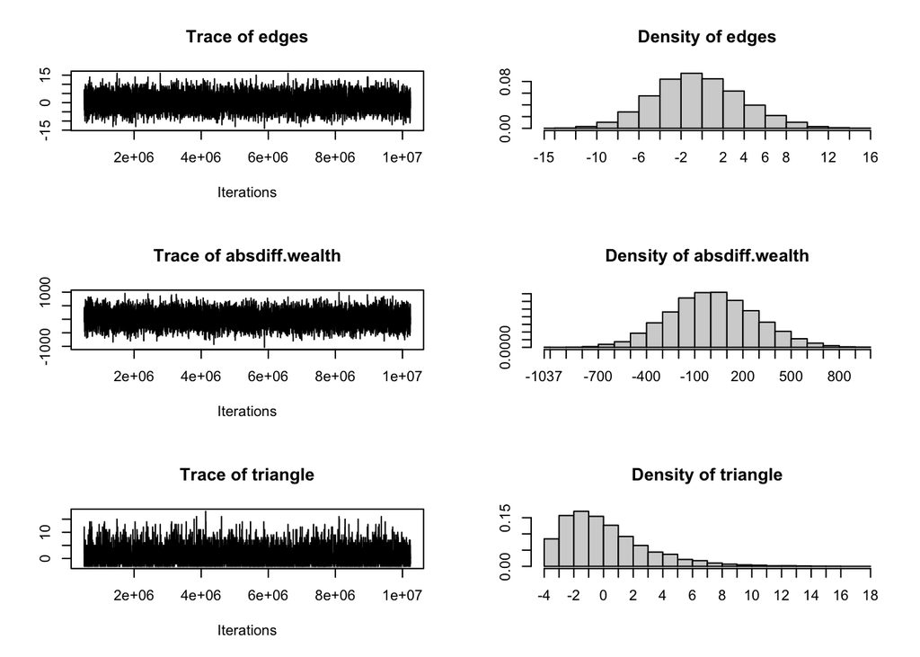

[output not shown]

The figure shows the results of the simulations. For each of the network statistics (`edges`, `absdiff.wealth` and `triangle`) the left graph shows the time series of the monte carlo simulation. If the simulation is correct, this should look like a i.i.d. sample. The figure on the right, shows the density estimated from the time-series. In general this density should look like a normal with mean zero. So in this model, we are immediately aware of a problem with the `triangles`. Indeed notice that the distribution does not look symmetric at all, and it is quite irregular. The other network statistics `edges` and `absdiff.wealth` are much more regular.

This is actually not surprising for this class of models. In general, when we introduce the `triangles`, the simulations become unstable. Possible practical solution to these problems are: 1) get rid of the triangles from the model; 2) insert additional variables and see if that changes the diagnostics; 3) run the estimation again, increasing the number of simulations.  
This problem has to do with the so-called `degeneracy` problem of ERGMs. Given the network data, some parameters will imply very high probability for networks that are implausible: for example some model will imply probability of almost 1 for a network where everybody is connected; other models imply very high probability for models where nobody is connected. When this happens, the simulation does not work well, and our estimates are suspicious. The most practical way to deal with this issue, is to run the diagnostics and figure out if there is any problem. If that is the case, we can change the formula of our model and estimate a different model. In general there is no easy fix.